# Assessment

Sara

2024-11-01

Note: No generative AI was used in this assessment.

### Opioid Drug Prescriptions Trends

NHS England (2023) has reported that a framework has been implemented in order to “reduce inappropriate prescribing” of opioids due to causing potential harm if interventions are not in place as well as addictive effects. Despite the use of opioid prescriptions being predominantly used for moderate to severe pain management, they are unlikely to be the “most clinically appropriate treatment for patients”. This report aims to assess the relationship between opioid drug prescriptions trends, opioid dependence and musculoskeletal pain in Scotland.

```r
library(tidyverse)
library(janitor) #makes data easier to use by tidying names
library(here)
library(knitr)
library(kableExtra) #for additional kable table editing choices
library(gt) #in order to generate a gt() table
```

### Classification of Opioid Data

Public Health Scotland’s ‘Prescriptions in the Community’ data was used, specifically from July 2024.

```r
prescription_data <- read_csv("https://www.opendata.nhs.scot/dataset/84393984-14e9-4b0d-a797-b288db64d088/resource/1cb425fc-640c-4b37-9013-f8e97f274085/download/pitc202407.csv") %>%
  clean_names()
```

These drugs were selected as they are the most prescribed opioids in the UK, however, there is data that isn’t relevant and should be filtered out such as oral solutions, solutions for injection ampoules, linctus sugar free, patches, tramadol prescribed with paracetamol etc. I only want to look at tablets/capsules. The code below will keep data with “tablets/capsules”. only.

```r
opioid_drugs <- c("TRAMADOL", "CODEINE", "BUPRENORPHINE", "OXYCODONE", "MORPHINE")
# A vector was created to specify the opioids that will be looked at for this assessment.

opioid_data <- prescription_data %>%
  filter(bnf_item_description != "TRAMADOL 37.5MG / PARACETAMOL 325MG TABLETS",
         #filtering out unnecessary paracetamol data
         str_detect(bnf_item_description, paste(opioid_drugs, collapse = "|")),
         #the collapse function condenses the vector made earlier
         str_detect(bnf_item_description, "TABLETS|CAPSULES")) %>%
  filter(!is.na(bnf_item_description)) #filtering out NA values
```

This filtered data was then used in order to generate a summary table. The output below groups the different opioid dosages together in order to make it easier to analyse and evaluate the results.

```r
# the code below will group the rows with the same name in the drug column and add their paid quantity values together
paid_quantity <- opioid_data %>%
  group_by(bnf_item_description) %>%
  summarise(total_paid_quantity = sum(paid_quantity))

# the code below will group the rows with the same name in the drug column, count the number of instances and calculate the proportion over the total number of observations in the 'opioid_data' dataset
sum_opioid <- opioid_data %>%
  group_by(bnf_item_description) %>%
  summarise(total_count = n()) %>%
  group_by(bnf_item_description, total_count) %>%
  summarise(proportion = ((total_count/6740)*100))

new_opioid_data <- full_join(paid_quantity, sum_opioid, join_by(bnf_item_description)) %>%
  select(bnf_item_description, total_count, proportion, total_paid_quantity) %>%
# the filtered data was then joined by the drug column and the select function was used to reorder the columns into a particular order
  mutate(opioid_class = case_when(
    str_detect(bnf_item_description, "TRAMADOL") ~ "Tramadol",
    str_detect(bnf_item_description, "^CODEINE") ~ "Codeine",
    str_detect(bnf_item_description, "DIHYDROCODEINE") ~ "Dihydrocodeine",
    str_detect(bnf_item_description, "BUPRENORPHINE") ~ "Buprenorphine",
    str_detect(bnf_item_description, "MORPHINE") ~ "Morphine")) %>%
  # this was done in order to group all of the dosages with the same name, e.g. all of the tramadol dosages together into one row etc.
  select(opioid_class, total_count:total_paid_quantity) %>%
  # the select function was used to reorder the columns into a particular order
  group_by(opioid_class) %>%
  summarise(across(c(total_count, proportion, total_paid_quantity), sum)) %>%
  # adding all of the values for the corresponding opioid
  arrange(desc(total_count)) #arranges the data by the highest values

opioid_table <- new_opioid_data %>%
  kable(col.names = c("Opioid Type", "Prescription Count", "Proportion of Prescribed Opioids (%)",
                      "Total Paid Quantity"),
        digits = 2,
        # rounds the columns with decimals to 2 decimal places
        align = "c",
        caption = "Figure 1: Information on Opioid Data - July 2024 Prescriptions",
        format.args = list(big.mark = ",")) %>%
  # places commas every three digits to make larger numbers easier to read
  kable_styling(bootstrap_options = "striped",
                full_width = F,
                position = "float_right")
# makes the table position to the right and wraps text

opioid_table %>%
  kable_styling()
```

Figure 1: Information on Opioid Data - July 2024 Prescriptions

| Opioid Type | Prescription Count | Proportion of Prescribed Opioids (%) | Total Paid Quantity |
| --- | --- | --- | --- |
| Tramadol | 3,295 | 48.89 | 7,218,217 |
| Codeine | 2,070 | 30.71 | 2,345,241 |
| Dihydrocodeine | 1,059 | 15.71 | 5,291,886 |
| Buprenorphine | 315 | 4.67 | 121,872 |
| Morphine | 1 | 0.01 | 90 |

Figure 1 involves looking at the combined raw count of the specified opioids, and subsequently their proportion by percentage, along with their paid quantity sum.

Tramadol accounts for the majority of prescribed opioids in both proportion and total paid quantity. However, due to the fact that *all* dosages of tramadol were grouped when generating this figure, this likely contributes to the large proportion seen. Dihydrocodeine and codeine account for the second largest majority of total paid quantity and proportion respectively. The proportion of opioids decreases significantly when considering both buprenorphine and morphine, only accounting for 4.68% of the total prescribed opioids.

### Prescribed Opioids Per Person in Each Health Board

NHS Health Board names and corresponding population data was used for this section. The data was sourced from Public Health Scotland’s ‘Geography Codes and Labels’ dataset and Scotland’s Census 2022 - UV103/ Health Board Area 2019’ from UK Data Service respectively. These datasets were joined with the previously filtered opioid data.

```r
##loading and joining data
health_boards <- read_csv("https://www.opendata.nhs.scot/dataset/9f942fdb-e59e-44f5-b534-d6e17229cc7b/resource/652ff726-e676-4a20-abda-435b98dd7bdc/download/hb14_hb19.csv") %>%
  clean_names()

opioid_data <- full_join(health_boards, opioid_data, join_by(hb == hbt)) %>%
  select(-c(3:5))
# the opioid data is now joined with the health board data,, with the 'hb_date_enacted', 'hb_date_archived' and 'country' columns removed as they are not required

population_data <- read_csv("https://s3-eu-west-1.amazonaws.com/statistics.digitalresources.jisc.ac.uk/dkan/files/2022/NRS/UV103/census_2022_UV103_age_Health_Board_Area_2019.csv", skip = 10) %>%
  rename(Spare = "...5", hb_name = "Health Board Area 2019", hb_population = Count) %>%
  filter(Age == "All people") %>%
  select(hb_name, hb_population) %>%
  mutate(hb_name = paste("NHS", hb_name)) #this includes the word 'NHS' before every 'hb_name' row
population_opioid_data <- full_join(population_data,
                                    opioid_data, join_by(hb_name))
```

Tramadol, codeine and dihydrocodeine were selected as they comprised the highest proportion of opioids. They were then each filtered separately and, using the population data, had their quantity per head calculated. This data was then joined together by Health Board and made longer in order to plot the stacked bar chart.

```r
# the quantity per head was calculated by adding the paid quantity of the opioid together and dividing it by the corresponding health board population to get the 'per head' data
tramadol_per_head <- population_opioid_data %>%
  filter(str_detect(bnf_item_description, "TRAMADOL")) %>%
  group_by(hb_name) %>%
  summarise(tramadol_quantity_per_head = sum(paid_quantity)/mean(hb_population))

codeine_per_head <- population_opioid_data %>%
  filter(str_detect(bnf_item_description, "^CODEINE")) %>%
  group_by(hb_name) %>%
  summarise(codeine_quantity_per_head = sum(paid_quantity)/mean(hb_population))

dihydrocodeine_per_head <- population_opioid_data %>%
  filter(str_detect(bnf_item_description, "DIHYDROCODEINE")) %>%
  group_by(hb_name) %>%
  summarise(dihydrocodeine_quantity_per_head = sum(paid_quantity)/mean(hb_population))

opioid_per_head <- list(tramadol_per_head, codeine_per_head, dihydrocodeine_per_head)
# a list was created in order to reduce and join the data in the next step

opioid_per_head_data <- opioid_per_head %>%
  reduce(full_join, by='hb_name') %>%
# the reduce full join is done to simultaneously merge data frames in a list
  pivot_longer(tramadol_quantity_per_head:dihydrocodeine_quantity_per_head,
               names_to = "opioid", values_to = "per_head")
# pivot longer was required to create a column with the opioids sperate to the values in order to plot figure 2
```

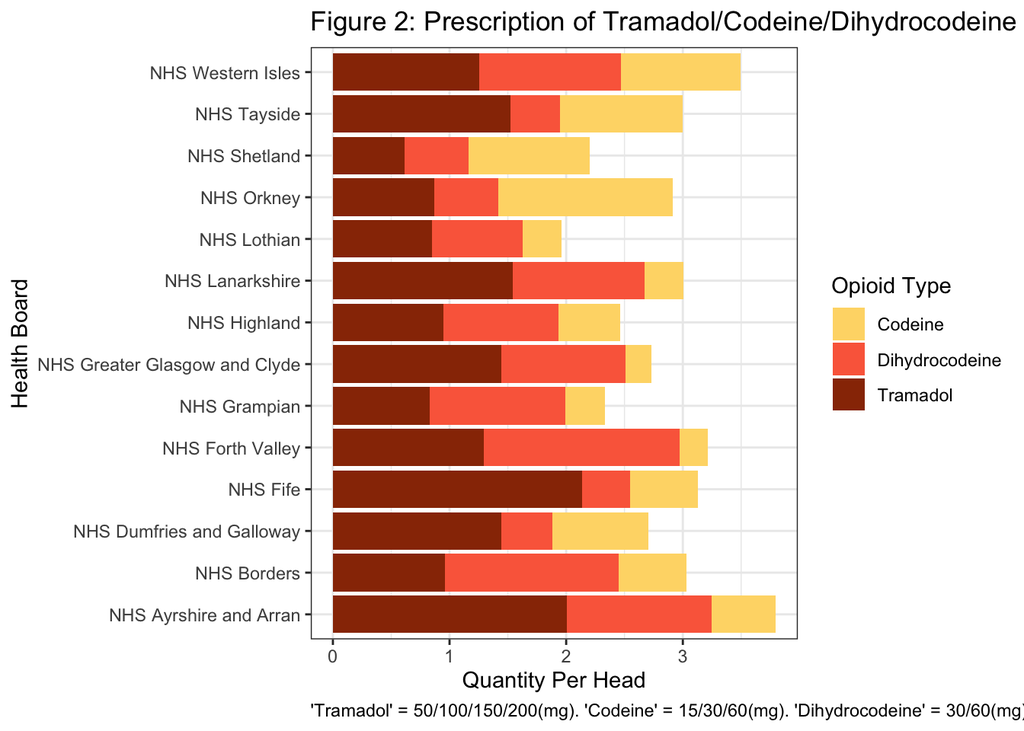

```r
opioid_per_head_chart <- opioid_per_head_data %>%
  ggplot(aes(x = hb_name, y = per_head)) +
  geom_col(aes(fill = opioid)) +
  #this makes the bar chart stacked
  coord_flip() +
  # as the healthboard names are quite long and overlap
  theme_bw() +
  labs(title = "Figure 2: Prescription of Tramadol/Codeine/Dihydrocodeine Per Person in Each Health Board",
       x = "Health Board",
       y = "Quantity Per Head",
       caption = "'Tramadol' = 50/100/150/200(mg). 'Codeine' = 15/30/60(mg). 'Dihydrocodeine' = 30/60(mg)") +
  scale_fill_discrete(name = "Opioid Type",
                      labels = c("Codeine", "Dihydrocodeine", "Tramadol"),
                      #changes the names of the figure legend title and variables
                      type = c("#FED976", "#FB6A4A", "#993404")) +
    theme(plot.caption = element_text(hjust=0))
# moves the caption to the left-hand side
opioid_per_head_chart
```

Figure 2 involves looking at the number of opioids prescribed per head in each health board. NHS Ayrshire and Arran had the overall highest proportion of combined opioids per head at approximately 3.8 per head. In terms of specific opioid class, the highest proportion of tramadol per head was approximately 2.1, with the lowest at approximately 0.6 in NHS Fife and NHS Shetland respectively. The highest proportions of dihydrocodeine and codeine per head, 1.7 at NHS Forth Valley and 1.5 at NHS Orkney respectively, are still notably lower than tramadol.

Although there is no clear relationship between Health Boards and opioid prescription rates, there is still a large quantity of opioids prescribed overall, suggesting problems either with over-prescriptions from GP practices or prevalence of systemic health problems such as chronic pain, perhaps as a result of lifestyle or work profession.

### Relationship Between No. of Musculoskeletal Pain Referrals and No. of Tramadol Sales

Following the previous section, I found that it would be interesting to see if there is a relationship between the number of referrals related to musculoskeletal (MSK) pain and the paid quantities of opioids, specifically tramadol as they make up the majority of the prescribed opioids. The data for this plot was sourced from Public Health Scotland’s ‘Allied Health Professionals - Musculoskeletal Waiting Times/ Referrals’ dataset.

This data set was joined with the aforementioned health board data names dataset and filtered for March of 2024, specifically looking at ‘referrals per one hundred thousand population’ to allow for standardisation of data as well as fair comparisons when analysing. Tramadol was filtered from the opioid dataset from earlier and the paid quantity per health board was summarised. After this, the filtered and summarised data was joined to generate Figure 3.

```r
# Required data
msk_hospital_referrals_data <- read_csv("https://www.opendata.nhs.scot/dataset/959f2341-ca34-428c-8abb-b925a18fc0c7/resource/8a7cc5e0-d779-4a5a-86f5-d9cb3695f4c5/download/open_data_ahp_msk_referrals_monthly_june2024.csv") %>%
  clean_names()

msk_hospital_referrals <- full_join(health_boards, msk_hospital_referrals_data, join_by(hb == hbt)) %>%
  # joined with data to see health board names
  select(-c(3:5)) %>%
  select(-c(specialty, number_of_referrals_qf,
            referrals_per_one_hundred_thousand_population_qf, number_of_referrals)) %>%
  filter(referral_source == "All Referral Sources",
         month == "202403", #most recent month was chosen
         !is.na(referrals_per_one_hundred_thousand_population),
         !hb == "S92000003") %>% #code corresponds to 'Scotland', isn't relevant
  group_by(hb, hb_name) %>%
  summarise(total_referrals_per100k= sum(referrals_per_one_hundred_thousand_population)) #this column was used to keep referrals and population standardised for comparison

tramadol_data <- opioid_data %>%
  filter(str_detect(bnf_item_description, "TRAMADOL")) %>%
  group_by(hb_name, bnf_item_description) %>%
  summarise(total_paid_quantity = sum(paid_quantity)) %>%
  #tramadol was filtered and then the total paid quantity was calculated for each dosage
  arrange(desc(total_paid_quantity)) %>%
  group_by(hb_name) %>%
  summarise(tramadol_paid_quantity = sum(total_paid_quantity)) %>%
  #the tramadol is now grouped together with the paid quantities appropriately added, with the corresponding health board
  arrange(desc(tramadol_paid_quantity))

tramadol_msk_data <- full_join(tramadol_data, msk_hospital_referrals, join_by(hb_name)) %>%
select(hb, hb_name, tramadol_paid_quantity, total_referrals_per100k)
#opioid and referral data was then joined and selected for a specific column order
```

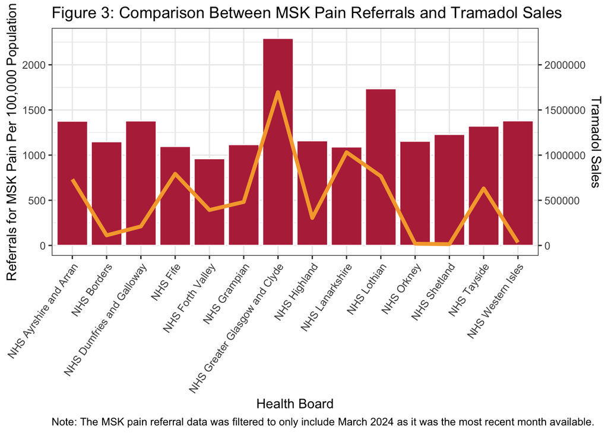

```r
# Graph data
tramadol_msk_plot <- tramadol_msk_data %>%
  ggplot() +
   geom_bar(aes(x = hb_name, y = total_referrals_per100k),
           stat ='identity', fill = "#B72E48", colour = "white") +
  geom_line(aes(x = hb_name, y = tramadol_paid_quantity/1000),
            group = 1, colour = "#F5A838", linewidth = 1.5) +
  #in order for 'scale_y_continuous' to work, the y-axis in the line graph must also be adjusted to be plot accurately
  scale_y_continuous(sec.axis = sec_axis(~.*1000, name = "Tramadol Sales")) +
  #allows a second y-axis to be plot and as the bar and line graph have very different scales, it is adjusted here to display both
  theme_bw() +
  theme(axis.text.x = element_text(angle = 55, hjust = 1, vjust = 1)) +
  #allows the health board names not to overlap as this plot cannot be flipped
  labs(title= "Figure 3: Comparison Between MSK Pain Referrals and Tramadol Sales",
       caption = "Note: The MSK pain referral data was filtered to only include March 2024 as it was the most recent month available.",
       x="Health Board", y="Referrals for MSK Pain Per 100,000 Population") +
theme(plot.caption = element_text(hjust=0))
#moves the caption to the left-hand side
tramadol_msk_plot
```

The regional variation in MSK pain and opioid use is similar to findings of other studies. For example, Todd et al. (2018) found that across England, there are “geographical differences in chronic pain prevalence, pain intensity and opioid utilisation” as well as finding results that indicate the presence of a ‘pain divide’. This is consistent with findings from the ‘Scottish Health Survey’ report (2022) which found that among individuals with chronic pain, the prevalence was “higher in the most deprived areas (50%) compared with the least deprived (29%)”.

### Opioid Prescriptions and Opioid Dependence Comparison in 2015 v 2020

Public Health Scotland’s ‘Estimated Prevalence of Opioid Dependence in Scotland’ data was used for this section, specifically information regarding opioid related hospitalisations and deaths. Public Health Scotland’s ‘Prescriptions in the Community’ data was also used, but from November in the years 2015 and 2020. These years were selected as 2020 was the most recent year in the opioid dependency dataset and for the sake of comparing changes over 5 years.

The ‘Prescriptions in the Community’ data was filtered the same way as the first section, with the 2015 and 2020 data joined after filtering. Using the data dictionary for the opioid dependency, hospitalisation and mortality data was identified and combined together, also sectioned for the years 2015 and 2020 for comparison.

```r
# required prescription data
prescription_data2015 <- read_csv("https://www.opendata.nhs.scot/dataset/84393984-14e9-4b0d-a797-b288db64d088/resource/49c2048d-a17c-42d0-b088-17332ffbf75d/download/pitc201511.csv") %>%
  clean_names() %>%
  select(hbt2014, paid_date_month, bnf_item_description, paid_quantity) %>%
  filter(!is.na(bnf_item_description)) %>%
  filter(str_detect(bnf_item_description, paste(opioid_drugs, collapse = "|")),
         str_detect(bnf_item_description, "TAB|CAP"),
         !str_detect(bnf_item_description, "PARACET")) %>%
  rename(hbt = hbt2014) #column is renamed so that 'bind_rows' can work later

prescription_data2020 <- read_csv("https://www.opendata.nhs.scot/dataset/84393984-14e9-4b0d-a797-b288db64d088/resource/ab8aa642-2562-4abb-a360-5c5f9e7e349c/download/pitc202011.csv") %>%
  clean_names() %>%
  select(hbt, paid_date_month, bnf_item_description, paid_quantity) %>%
  filter(!is.na(bnf_item_description)) %>%
  filter(str_detect(bnf_item_description, paste(opioid_drugs, collapse = "|")),
         str_detect(bnf_item_description, "TAB|CAP"),
         !str_detect(bnf_item_description, "PARACET"))

opioid_prescriptions_5_years <- bind_rows(prescription_data2015, prescription_data2020) %>%
  mutate(year = case_when(str_detect(paid_date_month, "2015") ~ "2015",
                          str_detect(paid_date_month, "2020") ~ "2020")) %>%
  #years changed so it is displayed clearly in figure 4
   mutate(opioid_class = case_when(
     str_detect(bnf_item_description, "TRAMADOL") ~ "Tramadol",
     str_detect(bnf_item_description, "^CODEINE") ~ "Codeine",
     str_detect(bnf_item_description, "DIHYDROCODEINE") ~ "Dihydrocodeine",
     str_detect(bnf_item_description, "BUPRENORPHINE") ~ "Buprenorphine",
     str_detect(bnf_item_description, "MORPHINE") ~ "Morphine")) %>%
  select(hbt, year, opioid_class, paid_quantity)
#'paid_data_month' and 'bnf_item_description' were not included as they are not relevant here

opioid_prescriptions_5_years_data <- opioid_prescriptions_5_years %>%
  group_by(year, opioid_class) %>%
  summarise(total_paid_quantity = sum(paid_quantity)) %>%
  filter(!is.na(opioid_class)) %>%
  pivot_wider(names_from = year, values_from = total_paid_quantity) %>%
  rename(Category = opioid_class) %>%
  arrange(factor(Category, levels = c("Tramadol", "Codeine", "Dihydrocodeine", "Buprenorphine"))) %>%
  #changed to dispaly in specific order
  mutate(Category = Category %>% factor() %>%
           fct_recode("Tramadol Sales" = "Tramadol",
                      "Codeine Sales" = "Codeine",
                      "Dihydrocodeine Sales" = "Dihydrocodeine",
                      "Buprenorphine Sales" = "Buprenorphine"))
#this was done as gt() tables display the data as is, therefore it had to be changed here

# required data
opioid_dependence_data <- read_csv("https://www.opendata.nhs.scot/dataset/2337c1d2-4e73-4cce-9039-1bce728108b2/resource/ead97aa5-307d-4d30-a048-3118f2f963fb/download/estimated_prevalence_of_opioid_dependence_scotland_data.csv") %>%
  clean_names()

opioid_dependence_clean <-  opioid_dependence_data %>%
  mutate(opioid_hospitalisations = deaths_unobserved + hospitalisations_unobserved + hospitalisations_cohort_off_oat) %>%
  #data dictionary was used in order to understand what columns should be combined
  mutate(opioid_deaths = deaths_cohort_on_oat + deaths_cohort_off_oat + hospitalisations_cohort_on_oat) %>%
  #data dictionary was used in order to understand what columns should be combined
  select(financial_year, age_group, opioid_hospitalisations, opioid_deaths) %>%
  group_by(financial_year, age_group) %>%
  summarise(across(c(opioid_hospitalisations, opioid_deaths), sum)) %>%
  mutate(financial_year = recode(financial_year, `2014/15` = "2015"),
         financial_year = recode(financial_year, `2019/20` = "2020")) %>%
  #years were changed to allow for comparison with opioid data
  group_by(financial_year) %>%
  summarise(across(c(opioid_hospitalisations, opioid_deaths), sum)) %>%
  filter(financial_year %in% c(2015, 2020)) %>%
  pivot_longer(opioid_hospitalisations:opioid_deaths, names_to = "Category", values_to = "Count") %>%
  pivot_wider(names_from = financial_year, values_from = Count) %>%
   mutate(Category = Category %>% factor() %>%
           fct_recode("Total Opioid Related Hospitalisations" =
                        "opioid_hospitalisations",
                      "Total Opioid Related Deaths" = "opioid_deaths"))
#both pivot longer and wider were required to format the data in a way that was required to display figure 4

opioid_change <- bind_rows(opioid_prescriptions_5_years_data, opioid_dependence_clean) %>%
  #data was joined together
gt() %>%
  tab_header(title = "Figure 4: Opioid Prescriptions and Opioid Related Hospitalisations/Deaths",
             subtitle = "Comparison Between 2015 and 2020") %>%
  tab_spanner(label = "Year", columns = c(`2015`, `2020`)) %>%
  opt_stylize(style = 1, color = "gray") %>%
  cols_align(align = "left", columns = Category) %>%
  cols_add(arrows = ifelse(`2015` < `2020`, "arrow-up", "arrow-down")) %>%
  #gt() icons were used in order to show arrows that highlight the changes in data, this is specifying the conditions for when the arrow should point up or down
   fmt_icon(columns = arrows, fill_color = c("arrow-up" = "green", "arrow-down" = "red")) %>%
  #this colours the arrows for better visualisation
  cols_label(arrows = "") %>% #this keeps the column name blank so that it does not appear as 'arrow' in the table
  fmt_number(sep_mark = ",", decimals = 0) #makes the large numbers easy to read and decimals kept appearing therefore I set the decimals to equal 0 so they wouldn't

opioid_change
```

Figure 4: Opioid Prescriptions and Opioid Related Hospitalisations/Deaths

Comparison Between 2015 and 2020

| Category | Year 2015 | Year 2020 |  |  |
| --- | --- | --- | --- | --- |
| Tramadol Sales | 8,775,116 | 7,300,975 |  |  |
| Codeine Sales | 1,166,175 | 1,754,712 |  |  |
| Dihydrocodeine Sales | 3,754,520 | 4,223,210 |  |  |
| Buprenorphine Sales | 33,776 | 163,317 |  |  |
| Total Opioid Related Hospitalisations | 457 | 656 |  |  |
| Total Opioid Related Deaths | 422 | 882 |  |  |

In summary, total opioid sales decreased by approximately 2.1% overall, due to the large effect tramadol has on overall sales. When considering the individual opioids, all sales increased, except for tramadol. The decrease in 2020 could have been as a result of the pandemic in that there may have been reduced tramadol prescriptions overall or even difficulty in terms of accessing these prescriptions. As seen in Figure 4, tramadol decreased by 16.8% and codeine, dihydrocodeine and buprenorphine increased by 50.5%, 12.5% and 383.5% respectively.

Interestingly, both opioid related hospitalisations and deaths also had a significantly large increase at 43.5% and 109% respectively. However, due to the fact that overall opioid sales decreased when comparing 2015 with 2020, this suggests that there is unlikely to be a relationship between the number of opioid prescribed and opioid related hospitalisations and deaths that the relationship is difficult to validate due to the effect of the pandemic. It would be interesting to compare changes after 2020 if more recent opioid dependency data was made available.

### References:

NHS England (2023) ‘Opioid prescriptions cut by almost half a million in four years as NHS continues crackdown’ Available at: https://www.england.nhs.uk/2023/03/opioid-prescriptions-cut-by-almost-half-a-million-in-four-years-as-nhs-continues-crackdown/ (Accessed: 12 November 2024)

Scottish Government (2023) ‘The Scottish Health Survey 2022 – volume 1: main report’ Available at: https://www.gov.scot/publications/scottish-health-survey-2022-volume-1-main-report/pages/9/ (Accessed: 22 November 2024)

Todd A, Akhter N, Cairns J, et al. (2018) ‘The Pain Divide: a cross-sectional analysis of chronic pain prevalence, pain intensity and opioid utilisation in England’ BMJ Open, 8(e023391). Available at: https://doi.org/10.1136/bmjopen-2018-023391 (Accessed: 22 November 2024)